# About Dataset :

The Fossil dataset was created to provide a comprehensive and realistic foundation for training and evaluating machine learning models aimed at predicting fossil ages. The dataset is of intermediate difficulty and includes a variety of geological, chemical, and physical attributes that are significant in the study of fossil formation and preservation.

# Features

**uranium_lead_ratio**: Ratio of uranium to lead isotopes in the fossil sample.

**carbon_14_ratio**: Ratio of carbon-14 isotopes present in the fossil sample.

**radioactive_decay_series**: Measurement of the decay series from parent to daughter isotopes.

**stratigraphic_layer_depth**: Depth of the fossil within the stratigraphic layer, in meters.

**isotopic_composition**: Proportion of different isotopes within the fossil sample.

**fossil_size**: Size of the fossil, in centimeters.

**fossil_weight**: Weight of the fossil, in grams.

**geological_period**: Geological period during which the fossil was formed.

**surrounding_rock_type**: Type of rock surrounding the fossil.

**paleomagnetic_data**: Paleomagnetic orientation data of the fossil site.

**stratigraphic_position**: Position of the fossil within the stratigraphic column.

**age**: Calculated age of the fossil based on various features, in years.

# EDA

```python
# check the unique values in categorical column
cols = ['paleomagnetic_data', 'geological_period' , 'surrounding_rock_type' , 'stratigraphic_position']

for col in cols:
    print(f'the unique values of {col} is: {df[col].unique()}')
    print('')
```

```
the unique values of paleomagnetic_data is: ['Normal polarity' 'Reversed polarity']

the unique values of geological_period is: ['Cretaceous' 'Cambrian' 'Permian' 'Devonian' 'Jurassic' 'Neogene'
 'Triassic' 'Paleogene' 'Ordovician' 'Carboniferous' 'Silurian']

the unique values of surrounding_rock_type is: ['Conglomerate' 'Limestone' 'Shale' 'Sandstone']

the unique values of stratigraphic_position is: ['Middle' 'Top' 'Bottom']
```

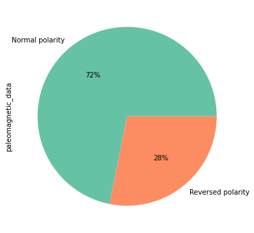

```python
# pie plot of paleomagnetic_data
pie_plot('paleomagnetic_data')
```

- 72% from all fossiles are nrmal polarity & the others are reversed.

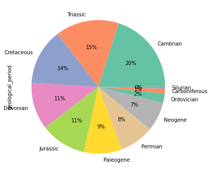

```python
# pie plot of geological_period
pie_plot('geological_period')
```

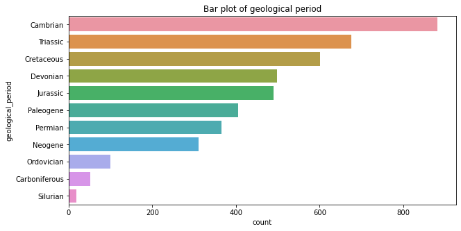

```python
plt.figure(figsize=(10,5))
sns.countplot(data = df, y ='geological_period', order = df['geological_period'].value_counts().index)
plt.title('Bar plot of geological period')
```

from the plots above, we deduced that the highest most frequent values in geological_period is **Cambian** (882 times), and the least one is **Silurian**. we could drop the rows of values silurian.

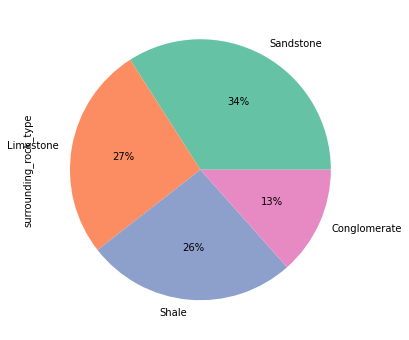

```python
# pie plot of surrounding_rock_type
pie_plot('surrounding_rock_type')
```

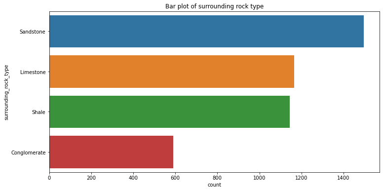

```python
plt.figure(figsize=(12,6))
sns.countplot(data = df, y ='surrounding_rock_type', order = df['surrounding_rock_type'].value_counts().index)
plt.title('Bar plot of surrounding rock type')
```

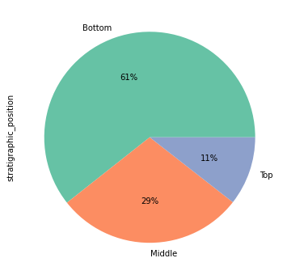

```python
## pie plot of stratigraphic_position
pie_plot('stratigraphic_position')
```

- **61%** from the fossiles was founded in the bottom , just **11%** of them founded in top and the others in the middle.

```python
### description of numerical data
df.describe()
```

|  | uranium_lead_ratio | carbon_14_ratio | radioactive_decay_series | stratigraphic_layer_depth | isotopic_composition | fossil_size | fossil_weight | age |
| --- | --- | --- | --- | --- | --- | --- | --- | --- |
| count | 4398.000000 | 4398.000000 | 4398.000000 | 4398.000000 | 4398.000000 | 4398.000000 | 4398.000000 | 4398.000000 |
| mean | 0.486938 | 0.430116 | 0.532054 | 152.832801 | 0.938315 | 70.702460 | 326.655177 | 40586.656435 |
| std | 0.257132 | 0.233536 | 0.287929 | 86.272234 | 0.521643 | 37.352584 | 187.032333 | 15200.700905 |
| min | 0.000241 | 0.000244 | 0.000076 | 0.130000 | 0.000275 | 0.130000 | 0.620000 | 4208.000000 |
| 25% | 0.294091 | 0.246269 | 0.316775 | 85.390000 | 0.533519 | 42.487500 | 181.047500 | 29766.250000 |
| 50% | 0.473715 | 0.416046 | 0.511830 | 146.000000 | 0.905684 | 68.785000 | 308.260000 | 39567.000000 |
| 75% | 0.658012 | 0.590752 | 0.723805 | 211.932500 | 1.289307 | 96.440000 | 455.520000 | 50550.500000 |
| max | 1.533270 | 1.000000 | 1.513325 | 494.200000 | 3.071434 | 216.390000 | 1010.090000 | 103079.000000 |

there are tree columns, we doubt that have outliers. **stratigraphic_layer_depth** , **fossil_size** , **fossil_weight**

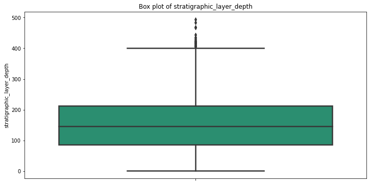

```python
plt.figure(figsize=(12, 6))
sns.boxplot(y=df['stratigraphic_layer_depth'], linewidth=2.5, palette='Dark2');
plt.title('Box plot of stratigraphic_layer_depth')
```

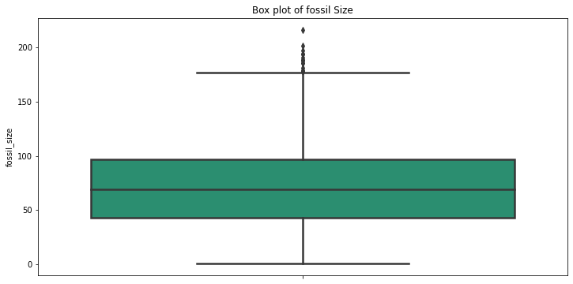

```python
plt.figure(figsize=(12, 6))
sns.boxplot(y=df['fossil_size'], linewidth=2.5, palette='Dark2');
plt.title('Box plot of fossil Size')
```

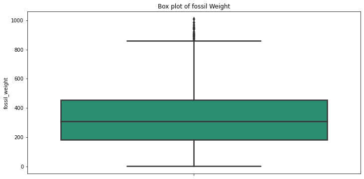

```python
plt.figure(figsize=(12, 6))
sns.boxplot(y=df['fossil_weight'], linewidth=2.5, palette='Dark2');
plt.title('Box plot of fossil Weight')
```

- All outliers can be handled using **Feature scaling**

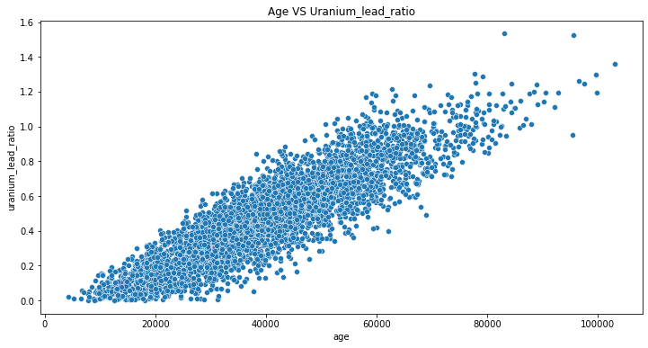

```python
# gettting the relation between uranium_lead_ratio & age of fossile
plt.figure(figsize=(12, 6))
sns.scatterplot(x='age', y='uranium_lead_ratio',data=df,palette='rocket')
plt.title('Age VS Uranium_lead_ratio')
plt.show()
```

- This indicates that there is a **positive** relationship between unranium ratio and age of the fossil.

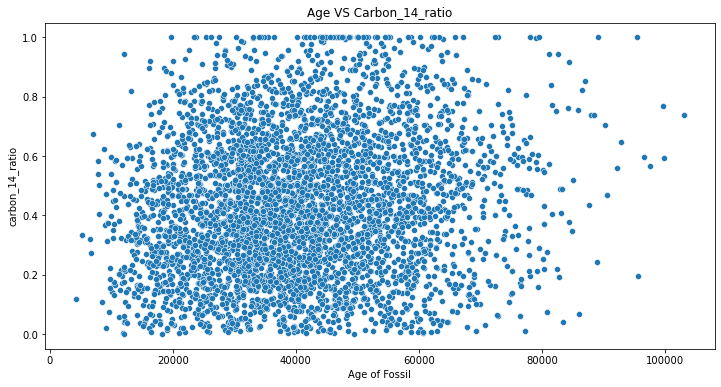

```python
# find the relation betweeen carbon_14 ratio & age of fossile
plt.figure(figsize=(12, 6))
sns.scatterplot(x='age', y='carbon_14_ratio',data=df ,palette='plasma')
plt.title('Age VS Carbon_14_ratio')
plt.xlabel('Age of Fossil')
plt.show()
```

- there is no any relation between two feature.

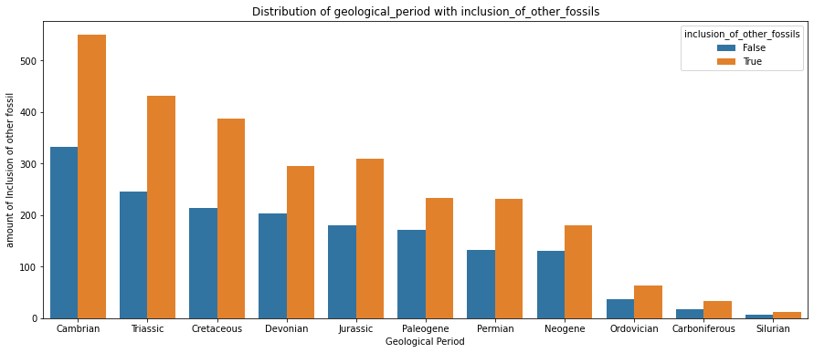

```python
plt.figure(figsize=(15, 6))

sns.countplot(x='geological_period', order=df['geological_period'].value_counts().index, data=df, hue='inclusion_of_other_fossils')
plt.title('Distribution of geological_period with inclusion_of_other_fossils')
plt.xlabel('Geological Period')
plt.ylabel('amount of Inclusion of other fossil')
plt.show()
```

- Plot above indicates that all gelogocal periods contains **high amount** of inclusion of other fossil.

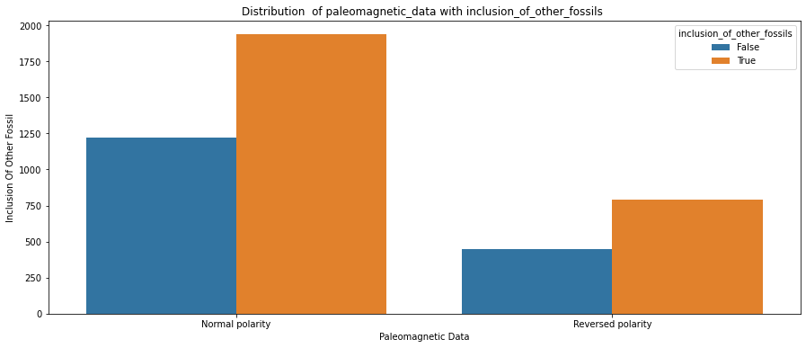

```python
plt.figure(figsize=(15, 6))
sns.countplot(x='paleomagnetic_data', order=df['paleomagnetic_data'].value_counts().index, data=df,
              hue='inclusion_of_other_fossils')

plt .xlabel('Paleomagnetic Data')
plt.ylabel('Inclusion Of Other Fossil')
plt.title('Distribution  of paleomagnetic_data with inclusion_of_other_fossils ')
plt.show()
```

- This is expected because the largest percentage from our data are normal polarity and contain inclusion of other polarity.

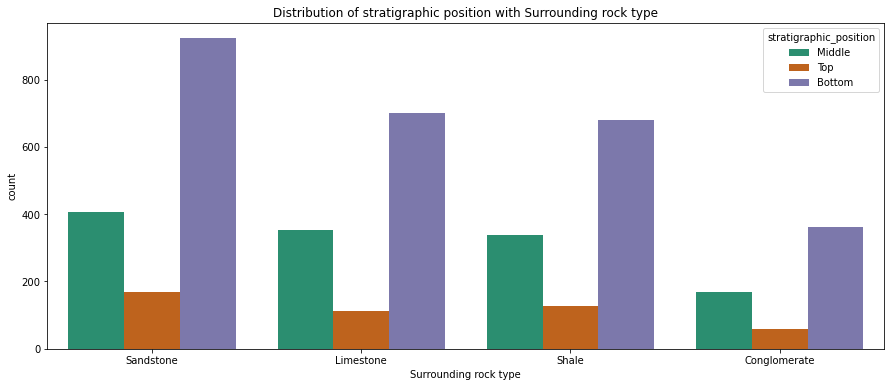

```python
plt.figure(figsize=(15, 6))
sns.countplot(x='surrounding_rock_type', order=df['surrounding_rock_type'].value_counts().index, data=df, hue='stratigraphic_position', palette='Dark2')
plt.title('Distribution of stratigraphic position with Surrounding rock type')
plt.xlabel('Surrounding rock type')
plt.show()
```

- Most fossils are founded in the bottom, So that at each rock type, the largest amount are founded in bottom and then middle.

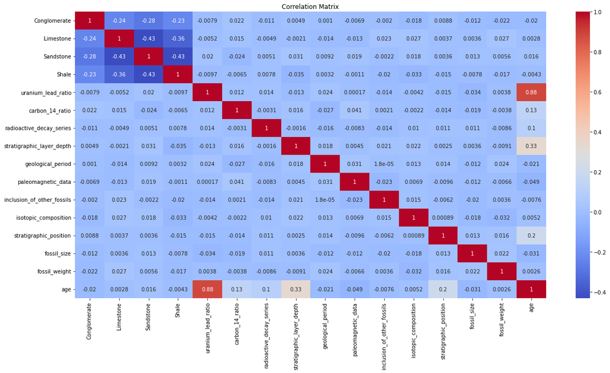

```python
### corellation
correlation_matrix=df.corr()
plt.figure(figsize=(20, 10))
sns.heatmap(correlation_matrix, cmap='coolwarm', annot=True)
plt.title('Correlation Matrix')
plt.show()
```

# Machine learning models

### Building Linear Regression Model

```python
from sklearn.linear_model import LinearRegression
from sklearn.metrics import mean_squared_error, r2_score , accuracy_score

# Initialize and train the Linear Regression model
linear_model = LinearRegression()
linear_model.fit(x_train, y_train)

# Make predictions
y_pred_linear = linear_model.predict(x_test)

# Evaluate the model
mse_linear = mean_squared_error(y_test, y_pred_linear)
r2_linear = r2_score(y_test, y_pred_linear)
# accuracy = accuracy_score(y_test , y_pred_linear)
print("Linear Regression Model")
print("Mean Squared Error:", mse_linear)
print("R^2 Score:", r2_linear)
```

```
Linear Regression Model
Mean Squared Error: 7867015.012296262
R^2 Score: 0.9676172832033293
```

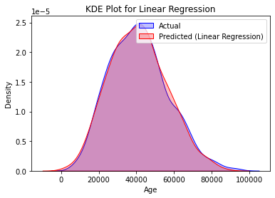

```python
# Plot KDE for Linear Regression
sns.kdeplot(y_test, label='Actual', color='blue', fill=True)
sns.kdeplot(y_pred_linear, label='Predicted (Linear Regression)', color='red', fill=True)
plt.title('KDE Plot for Linear Regression')
plt.xlabel('Age')
plt.ylabel('Density')
plt.legend()
```

### Building Gradient Boosting Model

```python
from sklearn.ensemble import GradientBoostingRegressor
from sklearn.linear_model import LinearRegression
from sklearn.metrics import mean_squared_error, r2_score

# Initialize and train the Gradient Boosting Regressor model
gb_model = GradientBoostingRegressor(n_estimators=100, learning_rate=0.1, max_depth=3, random_state=42)
gb_model.fit(x_train, y_train)

# Make predictions
y_pred_gb = gb_model.predict(x_test)

# Evaluate the model
mse_gb = mean_squared_error(y_test, y_pred_gb)
r2_gb = r2_score(y_test, y_pred_gb)

print("\nGradient Boosting Regressor Model")
print("Mean Squared Error:", mse_gb)
print("R^2 Score:", r2_gb)
```

```
Gradient Boosting Regressor Model
Mean Squared Error: 3821554.882642889
R^2 Score: 0.9842694682425123
```

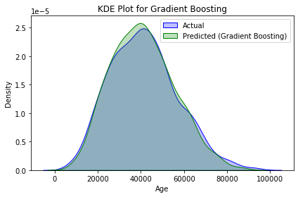

```python
# Plot KDE for Gradient Boosting Regressor
sns.kdeplot(y_test, label='Actual', color='blue', fill=True)
sns.kdeplot(y_pred_gb, label='Predicted (Gradient Boosting)', color='green', fill=True)
plt.title('KDE Plot for Gradient Boosting')
plt.xlabel('Age')
plt.ylabel('Density')
plt.legend()

plt.tight_layout()
plt.show()
```

[figure not shown]

```python
# Plotting
plt.figure(figsize=(12, 6))
sns.barplot(x='Model', y='Value', hue='Metric', data=model_comparison, palette="viridis")
plt.title('Model Comparison based on MSE and R^2 Score')
plt.xlabel('Model')
plt.ylabel('Value')
plt.show()
```